# Using DNA to solve NP Complete problems

## Introduction:

DNA Computing is defined as the “performing of computations using biological molecules, rather than traditional silicon chips”. The concept of using molecules for computation dates as back as 1959 where it all started with Richard Feynman an American physicist who made significant contribution to nanotechnology. (Martyn, 2012) DNA computing was only realized in 1994 by an American Computer Scientist, Leonard Alderman, who solved the famous Hamiltonian Path Problem (HPP) using biological Experiments. The HPP Problem is known to be NP-Complete and Alderman’s findings that HPP can solve a DNA based biological experiment is exciting because we know that speed of a computer, biological or not depends on two factors:

1. How many parallel processes it has;
2. How many steps each can perform per unit time

And it is no surprise biological computers are known to have a massive advantage due to their huge parallelism. The idea of harnessing the ability of DNA computing to vastly speed up many important computations is exciting and hence this project seeks to extend the Alderman method in such a way that allows biological computers to change the way we do all computations, starting with using DNA experiments to solve the popular “SAT” problem.

## A Sample Model of DNA:

In order to explain how we can use DNA to solve SAT, we need to first understand how DNA behaves. DNA strands are sequences $\alpha_1$ …, $\alpha_k$ over the alphabet (A,C,G,T), Double strands of DNA (dsDNA) consist of two DNA sequences $\alpha_1$ …, $\alpha_k$ and $\beta_1$ …, $\beta_k$. The two strands need to satisfy the Watson-Crick Complementary condition which states that : for each i = 1,… k, $\alpha_k$ and $\beta_k$ must be complements. That means that A $\leftrightarrow$ T or C $\leftrightarrow$ G. Complementary sequences can anneal in an antiparallel fashion where $5^1$ and $3^1$ refer to the chemically distinct ends of the DNA strands.

We can perform quite a number of operations on Test-Tubes that contain DNA strands:

1. Duplicate- Create large numbers of copies of any short single strand. ( Short referring to at least 20)
2. Annealing - Creating dsDNA from complementary single strands by allowing them to anneal.
3. Extraction- Given a test tube of DNA we can extract sequences that contain some consecutive pattern.
4. Detection- Given a test tube, we can determine whether or not there are any DNA strands in it
5. Amplify- This operation replicates all the DNA strands in the test tube.

## Using DNA to solve SAT

Let G be a graph with$a_{1}$ ,$x_{1}$ ,$x_{1}$ ’, $x_{2}$ , $x_{2}$ ’, …., an+1, with edges constructed from ak to xk and $x_{k}’$ , and there is an edge from xk to $a_{k+1}$ and $a_{k}’$ to $a_{k+1}$ . The path from a1 to an+1 has encode binary n-bit number. At each point there is two choices, 0 if the path is primed and 1 if the path is unprimed. Let take the following graph:

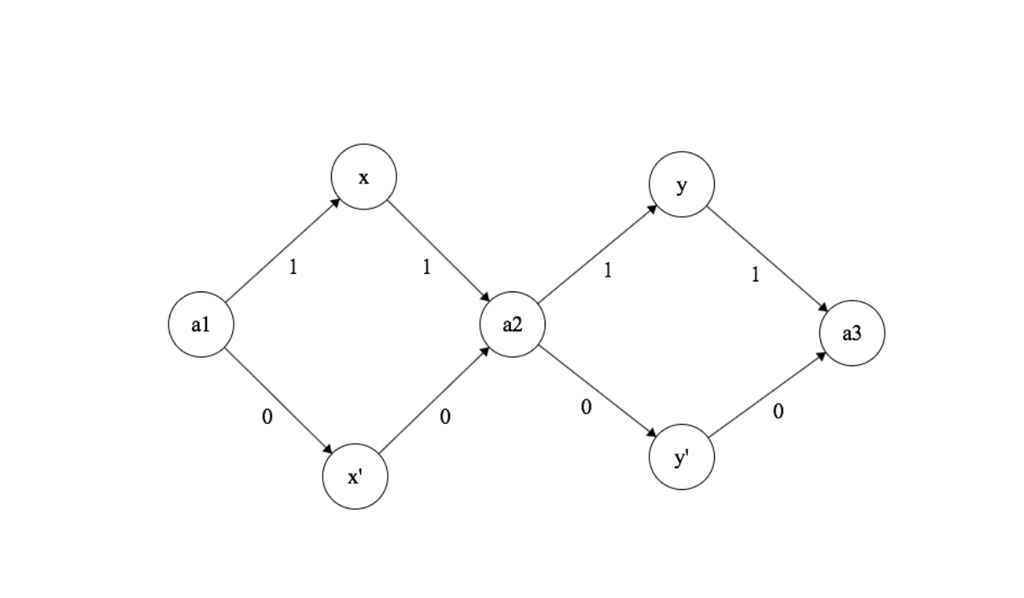

The path a1x’a2ya3 encodes the primary number 01.

Next we construct DNA test tube for the graph as following:

We assign a random DNA strand of length 20 for each vertex. The name of the vertex is divided into two parts pi and qi, so the name of the ith vertex has the name piqi. For the vertex we put 5’ → 3’ piqi DNA sequence. For the edges from i $\rightarrow$ j we put 3’ → 5’ the complement of piqi DNA sequence. To the initial vertex and the final vertex we add the half 3’ → 5’ the complement of piqi DNA sequence.

Any legal path in the graph G will correspond to correct double DNA-strand, this happens because 5’ → 3’ strands are the vertices and the 3’ → 5’ is the edges. The end of the vertex and the beginning of the edge can anneal since they are Watson-crick complements, so does the end of the edge and the beginning of the next vertex can also anneal.

Now that we have the DNA set up we can perform the extractions. For the extractions we will use E(t,i,a) operation, where t is the test tube we are extracting from, and i is the n-bit ( in our example if i is equal to 1, then it is the x value, and if it is 2 then it’s y) and final a = {0,1}, if a =0 then the value of the i is false and if a=1 then the value of it is true.

In this example the possible values are 00,01,10,11, and that is in the original test tube t0.

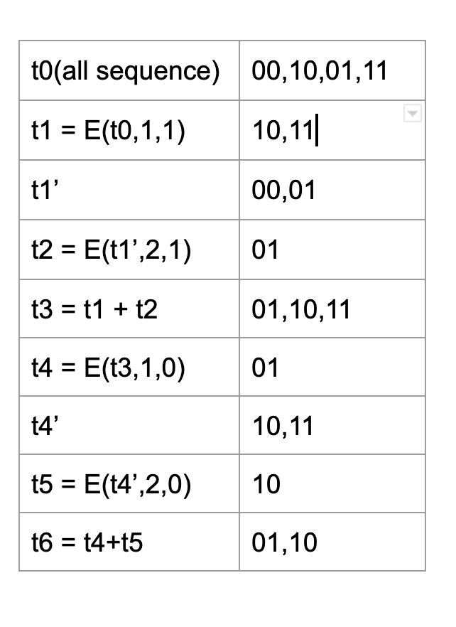

Notice that t3 satisfies the first clause, and t6 satisfies the two clause and the SAT.

## Proof:

In general: “Any SAT problem on n variables and m clauses can be solve with at most order m extract steps and one detect step.( number of steps is linear in m)  
Let $C_{1}$……$C_{m}$ be the clauses. We construct a series of test tubes $t-{0}$,….$t_{m}$ so that $t_{k}$ is the set of n-bit numbers x so that $C_{1}$(x) = $C_{2}$(x)=…..=$C_{m}$(x) = 1. Let $t_{k}$ be constructed, and we will construct $t_{k+1}$. Let $C_{k+1}$ be the clause $v_{1}$ $\vee ….\vee v_{l}$, where each $v_{i}$ is a literal or the complement of a literal. For some $x_{j}$ from set of x, if vi is equal to $x_{j}$ then E($t_{k}$, j, 1) and if it is equal to $x_{j}$’ then E($t_{k}$, j, 0). We perform each extraction and then use the reminder for the next one”

The main argument of the paper is the following:

“The SAT problem for formulas can be solved in a number of DNA experiments that are linear in the size of the formula.”

The above statement is proved for any contact network and not just for a formula.

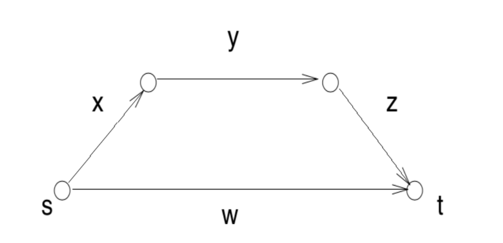

Figure: A simple contact network

$Def_{n}$: Contact Network: A contact network is a directed graph with a single special source s and a single special sink t. Each edge is labeled with either x or $\overline{x}$ where x is some variable, where x corresponds to a literal in the given SAT formula.

If there exists a satisfying assignment to the formula of the given SAT problem, then there exists a path from s to t.

## Proof:

The proof is broken down into two claims:

Claim 1: Given any formula of size S there is a contact network of size linear in S so that the set of assignments satisfy the formula as the network. If two formulas give the same value for any assignment to the variables, then these two formulas are equivalent. DeMorgan’s Laws can be used to place any formula into a normal form:

$\overline{x \vee y}$ = $x \wedge y$

and

$\overline{x \wedge y}$ = $x \vee y$

Assuming that the formulas are in a normal form, a contact network will be built which simulates the formula inductively.

E $\vee$ F : The network for E V F is constructed by placing G and H in parallel.

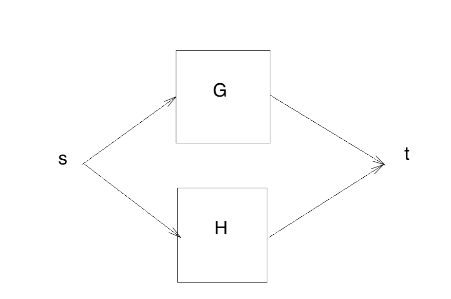

Figure: The “OR” case

E $\wedge$ F : The network for E $\wedge$ F is constructed by placing G and H in series.

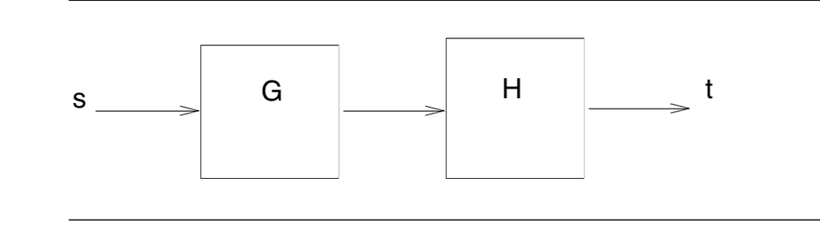

Figure: The “AND” case

Claim 2: Given any contact network of size S, in order S DNA experiments can solve the SAT problem for the network.

Each test tube is associated with a node in the contact network. Let a test tube, Pv be associated with the node v in G. This test tube will encode the set of assignments to the variables that connect s to v. There is a final test tube, $P_{t}$, which contains the answer. The following key (demonstrated for a single example) is used to obtain the set of assignments: Say, there is an edge from v to u , v $\rightarrow$ v, and that $P_{v}$ is already constructed. Then, P_{u} is constructed by performing the extraction E($P_{v}$, x, 1) ( or E($P_{v}$, x, 0) if there is no edge).

## Conclusion:

The question one might then proceed to ask is “Can we actually build DNA computers based on the methods described here” And the answer is YES! In 2002 J. Macdonald, D. Stefanovic and Mr. Stojanovic created a programmable molecular computing machine which could play tic-tac-toe. It comprised of enzymes and DNA molecules instead of silicon chips.(Minkel, 2006) In 2013, a JPEG photograph of a set of Shakespeare sonnets and an Audio file of Martin Luther King Jr’s “I have a dream“, were stored on DNA digital Storage. (Ehrenberg, 2013) Two other significant discoveries were made one using a biological transistor and another using a gene editing system. However, one complication all these had was that they were not reprogrammable and scientist David Doty described using a DNA computer as “like having to build a new computer out of new hardware just to run a new piece of software.” (Robitzski, 2019)

As we can imagine this was not at all efficient. However, fast forward to March 20, 2019, the first reprogrammable computer was built by David Doty and a team of scientists from UC Davis, California Institute of Technology, and Harvard. Prior to this, existing DNA could only run one program, but the team managed to program their computer to run 21 different programs. These programs can perform simple tasks such as counting, selecting options from a list, and recognizing palindromes. (Robitzski, 2019)

While conventional computers have a head start because of the many years that have been invested in their development, Doty’s discoveries are a breakthrough to the field as they equip us with computational flexibility take us one step closer to faster computation.

## Contributions:

Bushra: The proof : “The SAT problem for formulas can be solved in a number of DNA experiments that are linear in the size of the formula.“

Ratie: Worked on the Introduction, How DNA Works and the conclusion.

Umeyma: Explaining how to use DNA to solve SAT and the first proof

## References:

Dan Robitzski, March 22 2019, The World’s First Reprogrammable DNA computer is Here

Damien Woods, March 20, 2019, Diverse and robust molecular algorithms using reprogrammable DNA self-assembly

Ehrenberg Rachel, January 23, 2013, Scientists store and then retrieve 750 kilobytes of data in DNA

Martyn Amos, Nov 19, 2012, DNA computing, Britannica.com,

Minkel JR, October 18, 2006, DNA Computer Plays Complete Game of Tic-Tac-Toe’ DNA stores poems, a photo and a speech